# Predicting if Glass was from a Building

Ainsley Carlson

# Agenda

1. Introduction
2. Questions to Answer
3. Data Overview
4. Feature Engineering
5. Candidate Models
6. Model Identification Process
7. Results
8. Conclusions
9. Limitations

# Introduction

- Data comes from the USA Forensic Science Service
  - Featured 6 types of glass defined in terms of their oxide content
  - Real life data collected to test accuracy of classification methods
  - Donated to UC Irvine Machine Learning Repository on August 31, 1987
    - Link: https://archive.ics.uci.edu/dataset/42/glass+identification

# Questions of Interest

- Does a model with engineered features provides better than a model without them?
  - Better predictions can aid forensic investigations in determining where the glass came from
- How accurately can I predict if the glass was from a building?
- What variables will be important in predicting if glass was from a building?

# Dataset Decription

- Data originally contained 214 observations of 10 variables and no missing values with variable “Building” being created for this analysis
  - Variables are:
    - RI [Numeric]: refractive index
    - Na [Numeric]: Sodium weight percent in corresponding oxide
    - Mg [Numeric]: Magnesium weight percent in corresponding oxide
    - Al [Numeric]: Aluminum weight percent in corresponding oxide
    - Si [Numeric]: Silicon weight percent in corresponding oxide
    - K [Numeric]: Potassium weight percent in corresponding oxide
    - Ca [Numeric]: Calcium weight percent in corresponding oxide
    - Ba [Numeric]: Barium weight percent in corresponding oxide
    - Fe [Numeric]: Iron weight percent in corresponding oxide
    - Type [Categorical]: Glass type where type=1,2 are building windows, type=3,4 are vehicle windows, type=5 is containers, type=6 is tableware, and type=7 is headlamps.
    - Building [binary]: If the glass comes from a building or not, used for binary prediction variable.

# Exploratory Data Analysis

## Summary Statistics

```
       RI              Na              Mg              Al
 Min.   :1.511   Min.   :10.73   Min.   :0.000   Min.   :0.290
 1st Qu.:1.517   1st Qu.:12.91   1st Qu.:2.115   1st Qu.:1.190
 Median :1.518   Median :13.30   Median :3.480   Median :1.360
 Mean   :1.518   Mean   :13.41   Mean   :2.685   Mean   :1.445
 3rd Qu.:1.519   3rd Qu.:13.82   3rd Qu.:3.600   3rd Qu.:1.630
 Max.   :1.534   Max.   :17.38   Max.   :4.490   Max.   :3.500
       Si              K                Ca               Ba
 Min.   :69.81   Min.   :0.0000   Min.   : 5.430   Min.   :0.000
 1st Qu.:72.28   1st Qu.:0.1225   1st Qu.: 8.240   1st Qu.:0.000
 Median :72.79   Median :0.5550   Median : 8.600   Median :0.000
 Mean   :72.65   Mean   :0.4971   Mean   : 8.957   Mean   :0.175
 3rd Qu.:73.09   3rd Qu.:0.6100   3rd Qu.: 9.172   3rd Qu.:0.000
 Max.   :75.41   Max.   :6.2100   Max.   :16.190   Max.   :3.150
       Fe               Type        building
 Min.   :0.00000   Min.   :1.00   Length:214
 1st Qu.:0.00000   1st Qu.:1.00   Class :character
 Median :0.00000   Median :2.00   Mode  :character
 Mean   :0.05701   Mean   :2.78
 3rd Qu.:0.10000   3rd Qu.:3.00
 Max.   :0.51000   Max.   :7.00
```

# Variable Correlations

```
        RI      Na      Mg      Al      Si       K      Ca      Ba      Fe
RI  1.0000 -0.1919 -0.1223 -0.4073 -0.5421 -0.2898  0.8104 -0.0004  0.1430
Na -0.1919  1.0000 -0.2737  0.1568 -0.0698 -0.2661 -0.2754  0.3266 -0.2413
Mg -0.1223 -0.2737  1.0000 -0.4818 -0.1659  0.0054 -0.4438 -0.4923  0.0831
Al -0.4073  0.1568 -0.4818  1.0000 -0.0055  0.3260 -0.2596  0.4794 -0.0744
Si -0.5421 -0.0698 -0.1659 -0.0055  1.0000 -0.1933 -0.2087 -0.1022 -0.0942
K  -0.2898 -0.2661  0.0054  0.3260 -0.1933  1.0000 -0.3178 -0.0426 -0.0077
Ca  0.8104 -0.2754 -0.4438 -0.2596 -0.2087 -0.3178  1.0000 -0.1128  0.1250
Ba -0.0004  0.3266 -0.4923  0.4794 -0.1022 -0.0426 -0.1128  1.0000 -0.0587
Fe  0.1430 -0.2413  0.0831 -0.0744 -0.0942 -0.0077  0.1250 -0.0587  1.0000
```

- Refraction Index is highly correlated with Calcium with r=0.8104
  - Useful for performing K-means clustering

# Variable Distributions

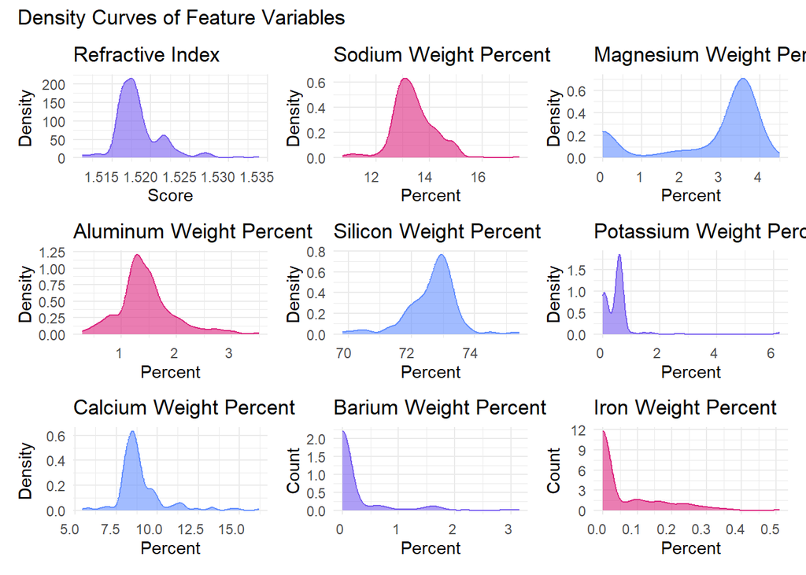

# Variable Distributions by if Glass was Building Glass

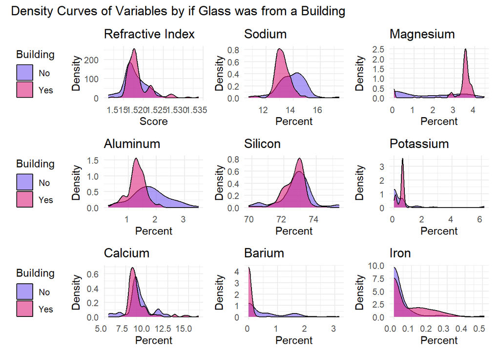

# Principal Component Analysis (PCA)

## PCA Vectors

Factor loadings of the PCA

|  | PC1 | PC2 | PC3 | PC4 | PC5 | PC6 | PC7 | PC8 | PC9 |
| --- | --- | --- | --- | --- | --- | --- | --- | --- | --- |
| RI | -0.56 | 0.18 | 0.16 | -0.15 | -0.11 | 0.19 | -0.04 | -0.74 | 0.11 |
| Na | 0.21 | 0.37 | -0.37 | -0.45 | 0.23 | -0.44 | -0.24 | -0.24 | -0.34 |
| Mg | -0.05 | -0.56 | -0.19 | -0.35 | 0.12 | 0.28 | 0.44 | -0.12 | -0.47 |
| Al | 0.41 | 0.21 | 0.47 | 0.09 | -0.08 | -0.28 | 0.63 | -0.28 | -0.08 |
| Si | 0.24 | -0.03 | -0.39 | 0.72 | 0.08 | 0.18 | -0.09 | -0.42 | -0.22 |
| K | 0.22 | -0.41 | 0.49 | -0.04 | -0.27 | -0.11 | -0.57 | -0.16 | -0.34 |
| Ca | -0.52 | 0.25 | 0.09 | 0.28 | -0.16 | -0.21 | 0.09 | 0.29 | -0.64 |
| Ba | 0.25 | 0.48 | 0.24 | -0.13 | 0.14 | 0.72 | -0.11 | 0.13 | -0.26 |
| Fe | -0.17 | -0.13 | 0.34 | 0.15 | 0.89 | -0.12 | -0.07 | -0.02 | 0.00 |

- Refractive Index is a major contributor to both PC1 and PC8
  - PC8 is repetive and will not contribute much new information
- Other major contributors are:
  - Magnesium,iron, barium, potassium, and calcium

# PCA Importance

The importance of each principal component

|  | PC1 | PC2 | PC3 | PC4 | PC5 | PC6 | PC7 | PC8 | PC9 |
| --- | --- | --- | --- | --- | --- | --- | --- | --- | --- |
| Standard deviation | 1.595248 | 1.477759 | 1.165573 | 1.082341 | 0.9371736 | 0.6541763 | 0.5838605 | 0.2678638 | 0.1500198 |
| Proportion of Variance | 0.282760 | 0.242640 | 0.150950 | 0.130160 | 0.0975900 | 0.0475500 | 0.0378800 | 0.0079700 | 0.0025000 |
| Cumulative Proportion | 0.282760 | 0.525400 | 0.676350 | 0.806510 | 0.9041000 | 0.9516500 | 0.9895300 | 0.9975000 | 1.0000000 |

- By PC6 approximately 95% of the total variance is controlled for
  - Only include up to PC6

# K-Means Clustering

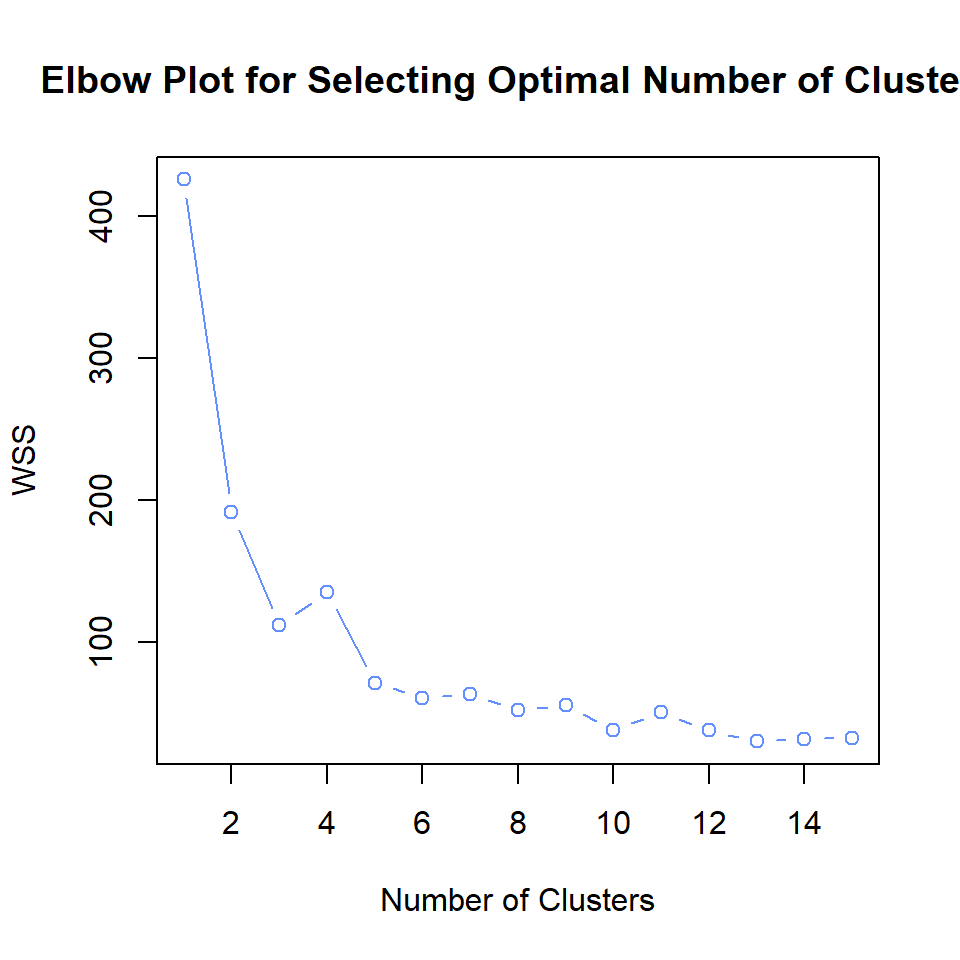

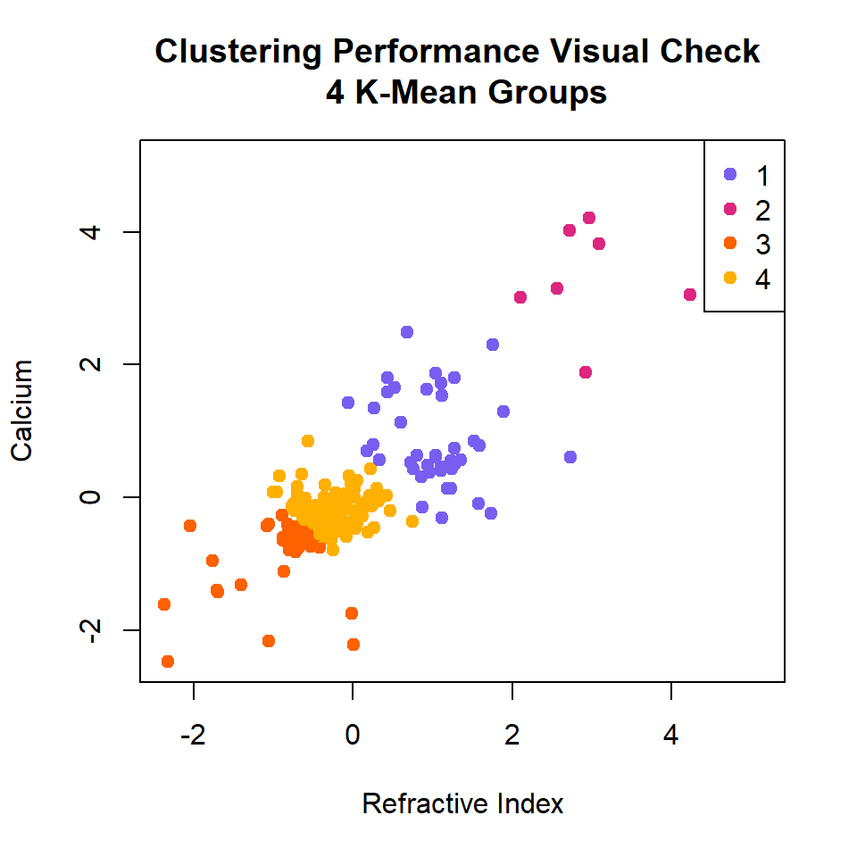

# Local Outlier Factor (LOF)

- The LOF isused to identify possible local outliers and can improve model prediction accuracy.
- Below are a comparison of LOF AUC scores at different numbers of K-nearest neigbors
  - LOF with 75 K-nearest neighbors appears to perform the best

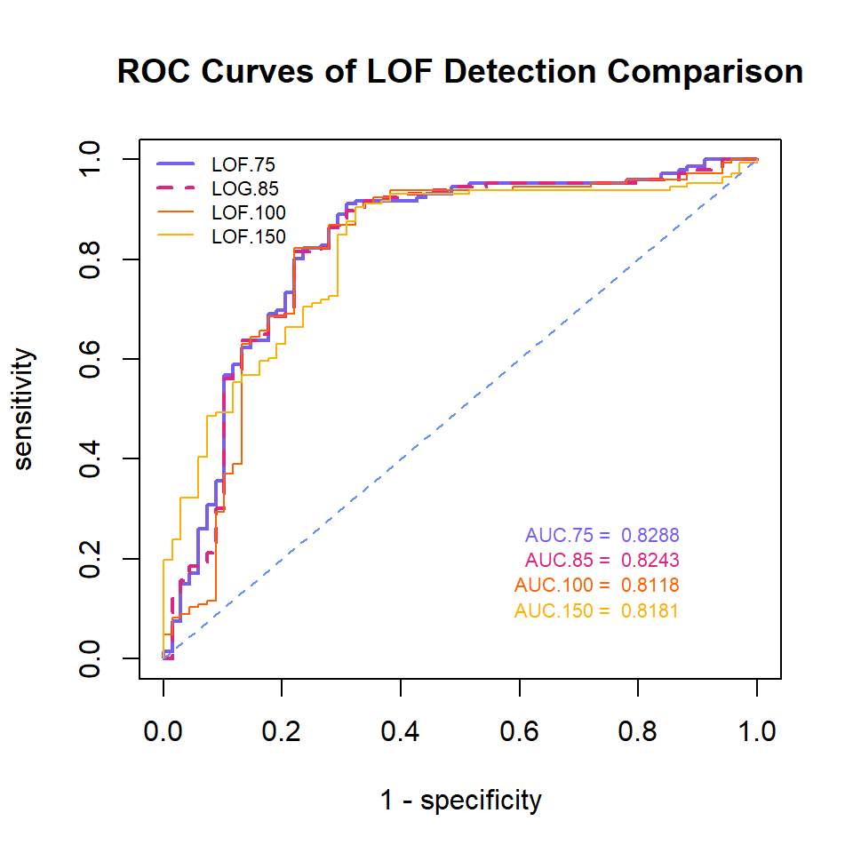

# Candidate Models

```
Call:
lm(formula = isbuilding ~ Mg + Na + Al + RI, data = glass)

Residuals:
     Min       1Q   Median       3Q      Max
-0.97362 -0.00414  0.10300  0.18470  0.74631

Coefficients:
             Estimate Std. Error t value Pr(>|t|)
(Intercept) -18.55675   14.83929  -1.251   0.2125
Mg            0.14853    0.02153   6.900 6.09e-11 ***
Na           -0.14446    0.03126  -4.621 6.68e-06 ***
Al           -0.14511    0.06461  -2.246   0.0258 *
RI           13.82203    9.64655   1.433   0.1534
---
Signif. codes:  0 '***' 0.001 '**' 0.01 '*' 0.05 '.' 0.1 ' ' 1

Residual standard error: 0.3458 on 209 degrees of freedom
Multiple R-squared:  0.4613,    Adjusted R-squared:  0.451
F-statistic: 44.74 on 4 and 209 DF,  p-value: < 2.2e-16
```

```
Call:
lm(formula = isbuilding ~ Ca + Na + lof + RI.pc, data = final.glass)

Residuals:
     Min       1Q   Median       3Q      Max
-0.99435 -0.03572  0.08624  0.18235  0.67201

Coefficients:
            Estimate Std. Error t value Pr(>|t|)
(Intercept)  5.08273    0.52743   9.637  < 2e-16 ***
Ca          -0.20472    0.03470  -5.899 1.45e-08 ***
Na          -0.17526    0.03120  -5.617 6.16e-08 ***
lof         -0.14008    0.03533  -3.965 0.000101 ***
RI.pc       -0.20376    0.03019  -6.749 1.44e-10 ***
---
Signif. codes:  0 '***' 0.001 '**' 0.01 '*' 0.05 '.' 0.1 ' ' 1

Residual standard error: 0.341 on 209 degrees of freedom
Multiple R-squared:  0.476, Adjusted R-squared:  0.466
F-statistic: 47.46 on 4 and 209 DF,  p-value: < 2.2e-16
```

# Model Identification Process

- Had two sets of data with the one only containing the original variables and the other containing the original variable and engineered variables
- For each set of data I created an intercept only model and a saturated model
- Then performed a stepwise regression going both forwards and backwards to find the best model for each set of data
- Stepwise regressions would be my two models for comparison as other models would be too computationally heavy to compare

# Results

# Bootstrapping Final Models: Histograms of AUC Scores

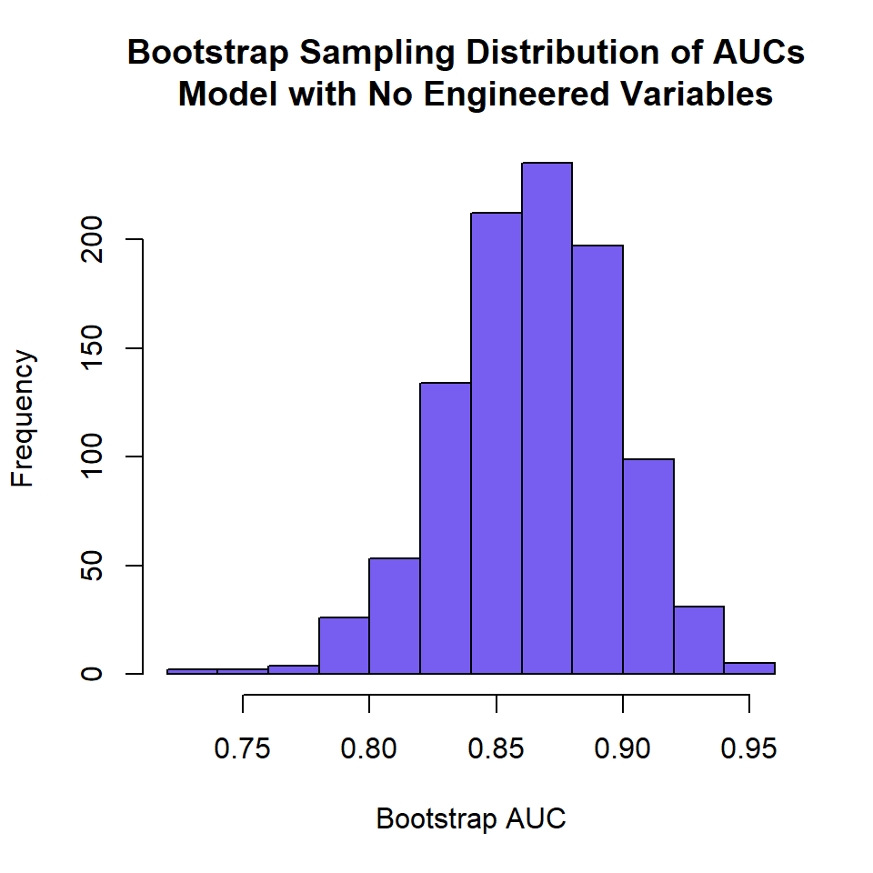

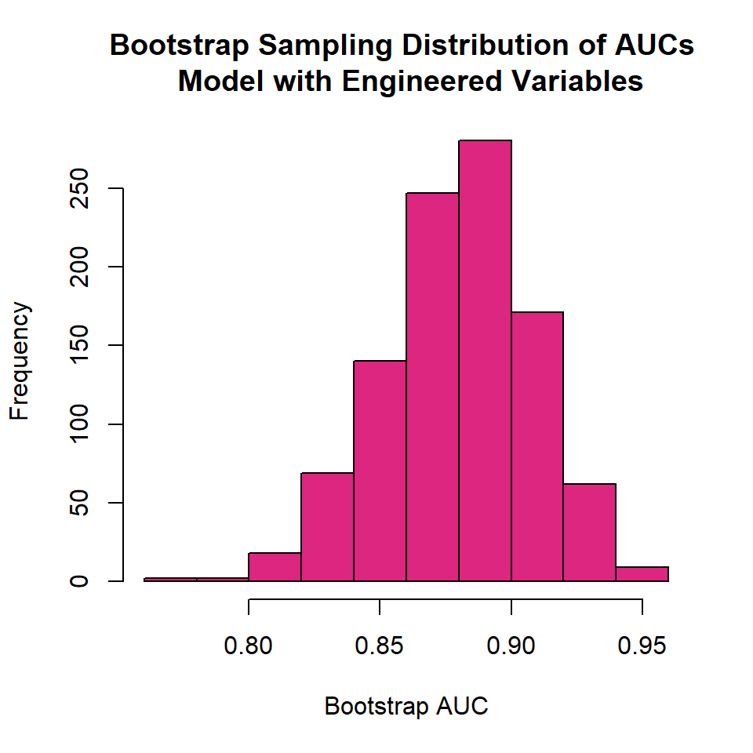

- Original variables model appears normally distributed with a slight left skew
- Engineered model has slightly higher range and smaller narrower distribution

# Bootstrapping Final Models: 95% Quantile and Mean of AUCs

Model with No Engineered Variables

| 2.5% | 97.5% |
| --- | --- |
| 0.7957 | 0.9252 |

```
[1] 0.8645927
```

Model with Engineered Variables

| 2.5% | 97.5% |
| --- | --- |
| 0.8213 | 0.9321 |

```
[1] 0.8798717
```

# Conclusion

- Engineered model had slightly higher average bootstrapped AUC than original variable model
  - Would have expected a larger improvement in AUC score with engineered model
- Original variables model is much simpler and less time consuming to identify
  - Do not have to create many different engineered variables
- Scenarios where even a slight improvement in AUC is valuable would benefit most from feature engineering
- It may be best to develop a model with the original variables in the data first

# Limitations